# Lab6

Drew Shives

10/20/2021

```r
library(tidyverse)
data <- read_csv("https://raw.githubusercontent.com/CrumpLab/statisticsLab/master/data/SchroederEpley2015data.csv")
data <- as_tibble(data)
```

```r
rand_test <- setRefClass("test_",
                     fields = list(),
                     methods = list(
                       means = function(seed, data, permutations) {
                         set.seed(seed)
                         pos_dif <- c()
                         col_names <- setNames(rep(0, 3), c("sample_group", "CONDITION", "mean"))
                         grouped_data <- bind_rows(col_names)[0, ]
                         for(i in 1:permutations) {
                           grouped_ <- data %>%
                             mutate(Intellect_Rating = sample(Intellect_Rating)) %>%
                             group_by(CONDITION) %>%
                             summarise(mean = mean(Intellect_Rating))
                           grouped_data <- grouped_data %>%
                             add_row(sample_group = i, CONDITION = grouped_$CONDITION, mean = grouped_$mean)
                         }
                         grouped_data
                       },

                       diff_means = function(seed, data, permutations) {
                         set.seed(seed)
                         pos_dif <- c()
                         col_names <- setNames(rep(0, 3), c("sample_group", "CONDITION", "mean"))
                         grouped_data <- bind_rows(col_names)[0, ]
                         for(i in 1:permutations) {
                           grouped_ <- data %>%
                             mutate(Intellect_Rating = sample(Intellect_Rating)) %>%
                             group_by(CONDITION) %>%
                             summarise(mean = mean(Intellect_Rating))
                           pos_dif[i] <- grouped_[grouped_$CONDITION == 1,]$mean - grouped_[grouped_$CONDITION == 0,]$mean
                         }
                         pos_dif
                       },

                       hist_means = function(seed, data, permutations) {
                         set.seed(seed)
                         pos_dif <- c()
                         col_names <- setNames(rep(0, 3), c("sample_group", "CONDITION", "mean"))
                         grouped_data <- bind_rows(col_names)[0, ]
                         for(i in 1:permutations) {
                           grouped_ <- data %>%
                             mutate(Intellect_Rating = sample(Intellect_Rating)) %>%
                             group_by(CONDITION) %>%
                             summarise(mean = mean(Intellect_Rating))
                           grouped_data <- grouped_data %>%
                             add_row(sample_group = i, CONDITION = grouped_$CONDITION, mean = grouped_$mean)
                         }
                         grouped_data_diff <- grouped_data %>%
                           group_by(sample_group) %>%
                           summarise(diff = mean[CONDITION == 1] - mean[CONDITION == 0])
                         ggplot(data = grouped_data_diff) +
                           geom_histogram(mapping = aes(x = diff))
                       },

                       prob_mean_diff = function(seed, data, permutations, prob_mean_diff) {
                         set.seed(seed)
                         pos_dif <- c()
                         col_names <- setNames(rep(0, 3), c("sample_group", "CONDITION", "mean"))
                         grouped_data <- bind_rows(col_names)[0, ]
                         for(i in 1:permutations) {
                           grouped_ <- data %>%
                             mutate(Intellect_Rating = sample(Intellect_Rating)) %>%
                             group_by(CONDITION) %>%
                             summarise(mean = mean(Intellect_Rating))
                           pos_dif[i] <- grouped_[grouped_$CONDITION == 1,]$mean - grouped_[grouped_$CONDITION == 0,]$mean
                         }
                         length(pos_dif[pos_dif >= prob_mean_diff]) / length(pos_dif)
                       }

                       )
                     )
```

```r
rand_test_output <- rand_test()

means <- rand_test_output$means(1, data, 1000)

diff_means <- rand_test_output$diff_means(1, data, 1000)

diff_hist <- rand_test_output$hist_means(1, data, 1000)

prob_mean_diff <- rand_test_output$prob_mean_diff(1, data, 1000, 2)


means
```

```
## # A tibble: 2,000 × 3
##    sample_group CONDITION  mean
##           <dbl>     <dbl> <dbl>
##  1            1         0  4.98
##  2            1         1  4.49
##  3            2         0  5.04
##  4            2         1  4.44
##  5            3         0  4.59
##  6            3         1  4.83
##  7            4         0  5.02
##  8            4         1  4.46
##  9            5         0  4.44
## 10            5         1  4.95
## # … with 1,990 more rows
```

```r
diff_means
```

```
##    [1] -0.489417989 -0.592592593  0.232804233 -0.558201058  0.507936508
##    [6]  0.645502646  0.198412698 -0.764550265 -0.214285714  0.095238095
##   [11]  0.198412698 -0.661375661 -0.867724868  0.267195767 -0.042328042
##   [16]  0.267195767  0.301587302  0.198412698 -0.351851852 -2.105820106
##   [21]  0.129629630 -0.351851852  1.264550265  0.164021164  0.164021164
##   [26]  0.198412698 -0.592592593  0.095238095 -0.936507937 -0.489417989
##   [31] -0.936507937  0.611111111  0.611111111  1.230158730 -0.626984127
##   [36]  0.645502646  0.542328042 -0.317460317 -0.042328042 -0.179894180
##   [41] -0.936507937  0.232804233 -0.695767196  0.267195767  0.817460317
##   [46]  0.783068783 -0.730158730 -0.455026455  0.232804233 -0.386243386
##   [51] -0.042328042  0.198412698  0.267195767 -1.142857143  0.370370370
##   [56]  1.023809524 -0.523809524 -0.042328042 -0.111111111  1.195767196
##   [61]  0.576719577  0.370370370 -0.248677249 -0.145502646 -1.074074074
##   [66] -0.248677249 -0.145502646 -0.936507937  0.851851852  0.679894180
##   [71]  0.542328042  0.611111111  0.507936508  0.370370370  0.198412698
```

[output cut: 185 more lines]

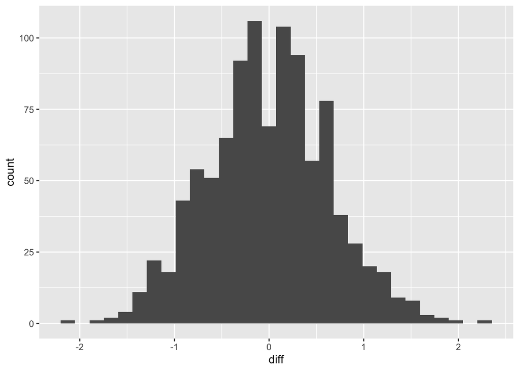

```r
diff_hist
```

```r
prob_mean_diff
```

```
## [1] 0.002
```

I decided to try and write a class object with a bunch of functions for the object. I split the class (rand_test()) into four methods:

(One note — set the seed as the same for each method to share the sampling data across each.)

- rand_test_output$means(seed, data, permutations)

Produces a tibble with all sample groups, conditions, and means for each condition in each sample group.

- rand_test_output$diff_means(seed, data, permutations)

Produces a vector of difference in sample means between conditions per sample group.

- rand_test_output$hist_means(seed, data, permutations)

Produces a histogram of all of the difference in sample means.

- rand_test_output$prob_mean_diff(seed, data, permutations, observered_mean_difference)

Produces the probability/odds of obtaining the mean difference or larger set by the parameter “observed_mean_difference”.

Given that we randomly sampled permutations of the data 1000 times and received a result of 0.002 for the probability of obtaining a mean difference of 2 (what was observed), it is likely that this difference was not produced by chance. That being said, however, considering that the sample size overall for the experiment is n = 39, it is still possible that the observed outcome could have been by chance.

If the observed mean difference was 0.5, I would believe strongly that the result was produced by chance rather than the experimental manipulation.

I was able to complete this lab with minimal assistance outside of Stack Overflow for some syntax questions (especially as relates to creating a class object and subsequent methods in R).